# The Strength of the Global Socio-Technical Pulp and Paper System and Its Consequences for Forestry Diversification

Philipp Jonas Kreutzer

philipp_jonas.kreutzer@ekh.lu.se

Department of Economic History, Lund University

Derek Garfield

derek.bradley.garfield@slu.se

Swedish University of Agricultural Sciences

Cristián Alarcón Ferrari

Swedish University of Agricultural Sciences

2024-11-28

## The Pulp and Paper Industry is Going Global

[figure not shown]

Figure 1: Yearly Pulp and Paper Production By Continent. Data from *FAOSTAT* (2024)

## Internationalization Changes Local Ecosystems

[video not shown]

# Global Sociotechnical Regimes

## Global Sociotechnical Regimes

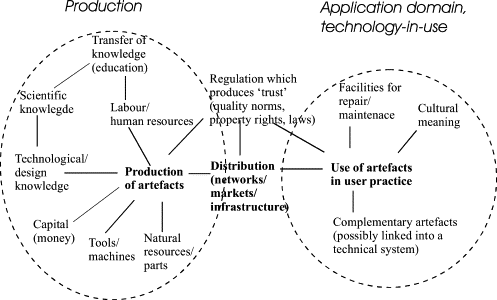

Figure 2: Sociotechnical Systems Connect Technology Production and Use to Fulfill Societal Functions, Reproduced from Geels (2004)

## Global Sociotechnical Regimes

> … the rule-set or grammar embedded in a complex of engineering practices, production process technologies, product characteristics, skills and procedures, ways of handling relevant artefacts and persons, ways of defining problems; all of them embedded in institutions and infrastructures (Rip & Kemp, 1998, p. 340)

## Global Sociotechnical Regimes

Regimes have spatial dimensions (Fuenfschilling & Binz, 2018)

[figure not shown]

Schematic adapted from Miörner et al. (2022)

### RQs

1. How strong is the global regime for pulp and paper?
2. Scale at which institutional rationalities develop?
3. Key actors and their relationships?
4. Conflicts and resolutions between global rationalities and local context?
5. Channel of transformation: Actors, Networks, Technologies, Insitituions?

# Data and Methods

**Primary Data on Pulp and Paper Production**

- Prices (U.S. Bureau of Labor Statistics, 2024)
- Production Statistics (*FAOSTAT*, 2024)

**Narrative Literature Review**

Research publications, books, and gray literature

Informs analysis of strength of global regime

**Case Studies**

| *Sweden* | *Chile* |
| --- | --- |
| Technology Exporter | Technology Importer |
| Traditional Forestry Country | New Forestry Actor |
| Boreal Forest | Temperate Forests |
| 🌲 *Picea abies*, *Pinus Sylvestris* | 🌲 *Pinus radiata*, 🌳 *Ecualyptus* |

Data Sources: Interviews, Case Studies, Financial and Strategy Documents

Informs sub-questions about global regime actors, effects and trends for countries

# Results

## Global North Appears Most Dominant in Developing Institutional Rationalities

- High international integration of Nordic forests since 18th century (Lehtinen et al., 2016)
- Nordic countries emerge as key technology producers in 20th century

## Few Key Actors Active in International Networks But Rooted In Global North

**Forestry**

[figure not shown]

**Pulp and Paper Mills**

[figure not shown]

[figure not shown]

## Key developments tied into global economic development, but even firm-level heterogenity in transitions

- Developments tightly connected to global economic demands, e.g. industrial revolution, demise of office paper and shipping boom (Beland Lindahl & Westholm, 2011)
- Individual technological systems exposed to firm-level heterogenity, e.g. pulping process in Swedish pulp mills (Ottosson & Magnusson, 2013; Soderholm & Soderholm, 2020)

## Global North exports technology, know-how, and rationality

- Technology key in transporting rationalities (Tahvanainen et al., 2024)
- Education mostly Global North based (Fuentealba et al., 2021; Manuschevich, 2016)

# Preliminary Key Takeaways

1. Sociotechnical system of pulp and paper production strongly globalized
2. Shared rationales about capital intensive, high-tech, automated and mechnized processes, developed in Global North and located with few actors
3. But space for local experimentation down to firm-level

## References

Beland Lindahl, K., & Westholm, E. (2011). Food, Paper, Wood, or Energy? Global Trends and Future Swedish Forest Use. *Forests*, *2*(1), 51–65. https://doi.org/10.3390/f2010051

*FAOSTAT*. (2024). https://www.fao.org/faostat/en/#data/FO/metadata.

Fuenfschilling, L., & Binz, C. (2018). Global socio-technical regimes. *Research Policy*, *47*(4), 735–749. https://doi.org/10.1016/j.respol.2018.02.003

Fuentealba, A., Duran, L., & Morales, N. S. (2021). The impact of forest science in Chile: History, contribution, and challenges. *Canadian Journal of Forest Research*, *51*(6), 753–765. https://doi.org/10.1139/cjfr-2020-0471

Geels, F. W. (2004). From sectoral systems of innovation to socio-technical systems: Insights about dynamics and change from sociology and institutional theory. *Research Policy*, *33*(6), 897–920. https://doi.org/10.1016/j.respol.2004.01.015

Lehtinen, A. A., Donner-Amnell, J., & Saether, B. (Eds.). (2016). *Politics of forests: Northern forest-industrial regimes in the age of globalization*. Routledge.

Manuschevich, D. (2016). Neoliberalization of forestry discourses in Chile. *Forest Policy and Economics*, *69*, 21–30. https://doi.org/10.1016/j.forpol.2016.03.006

Miörner, J., Heiberg, J., & Binz, C. (2022). How global regimes diffuse in space – Explaining a missed transition in San Diego’s water sector. *Environmental Innovation and Societal Transitions*, *44*, 29–47. https://doi.org/10.1016/j.eist.2022.05.005

Ottosson, M., & Magnusson, T. (2013). Socio-technical regimes and heterogeneous capabilities: The Swedish pulp and paper industry’s response to energy policies. *Technology Analysis & Strategic Management*, *25*(4), 355–368. https://doi.org/10.1080/09537325.2013.774349

Rip, A., & Kemp, R. (1998). Technological change. In *Human choice and climate change: Vol. II, resources and technology* (pp. 327–399). Battelle Press.

Soderholm, K., & Soderholm, P. (2020). Industrial energy transitions and the dynamics of innovation systems: The swedish pulp and paper industry, 1970-2010. *ENVIRONMENTS*, *7*(70). https://doi.org/10.3390/environments7090070

Tahvanainen, V., Laakkonen, A., Pesala, O., Pittaluga, L., Hujala, T., & Pykalainen, J. (2024). Pulp addiction? Perspectives of local regime actors on the development of the growing pulp industry in Uruguay. *FOREST POLICY AND ECONOMICS*, *164*(103248). https://doi.org/10.1016/j.forpol.2024.103248

U.S. Bureau of Labor Statistics. (2024). *Producer price index by commodity: Pulp, paper, and allied products: Wood pulp [WPU0911]*.